# Prosper Loan Data

## by Hamza Metawea

## Investigation Overview

Prosper is a peer-to-peer lending platform. Borrowers can find competitive rates for personal loans with one, three or five-year terms. Behind the scenes, loans are funded by investors, not Prosper itself. Prosper offers loan rates instantly without affecting your credit score. Our goal is to try to answer questions that we think it might be benficail to the an investor wants to invest his money,we will try to ansewr some question ralted to the factors affect EstimatedEffectiveYield and Return.

## Dataset Overview

This dataset is a financial dataset of the loans, borrowers, lenders, interest rates of Prosper or Prosper Marketplace Inc. which is a San Francisco, California based . So in this company you are rthier a borrower or an investor In this dataset, we are using the data from the Posper to analyse it and trying to find pattern and generate valuable insights and obseravation.The dataset is comprised of 81 variables and contains 113937 observations.

## (Distribution EstimatedEffectiveYield)

- let's look on distribution of the variable of interest: lender yield & EstimatedEffectiveYield
- PLot tends to be Truncated or Heart-Cut Distribution , the iEstimatedEffectiveYield looks normal distribution with the tails cut off and one out lier near rate = to 30% .

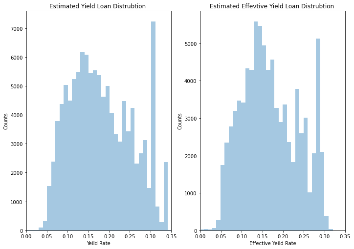

## (Distribution delinquent)

> the term "delinquent In the personal finance field, commonly refers to a situation where a borrower is late or overdue on a payment, such as income taxes, a mortgage, an automobile loan, or a credit card account. CurrentDelinquencie : Number of accounts delinquent at the time the credit profile was pulled. AmountDelinquent : Dollars delinquent at the time the credit profile was pulled.
> - statiscs showes more than 75% equals to 0
> - Plot also shows most of the data around 0 means that low level of Delinquencies gives a good sign for an investor

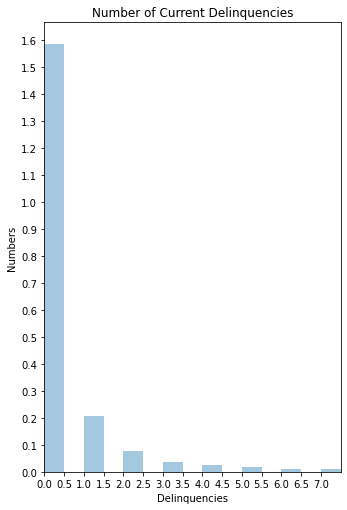

## (Distribution AvailableBankcardCredite)

> One of the important factors to the investor/lender is the AvailableBankcardCredite which isThe total available credit via bank card at the time the credit profile was pulled. Plot is Right skwed with one peak around 2000 which gives neagtive sign so far for an investor since most creditworthy applicants with stable incomes can expect credit card credit limits between 3500 and 7500 Dollars. High-income applicants with excellent credit might expect a credit limit of up to or more than 10000.

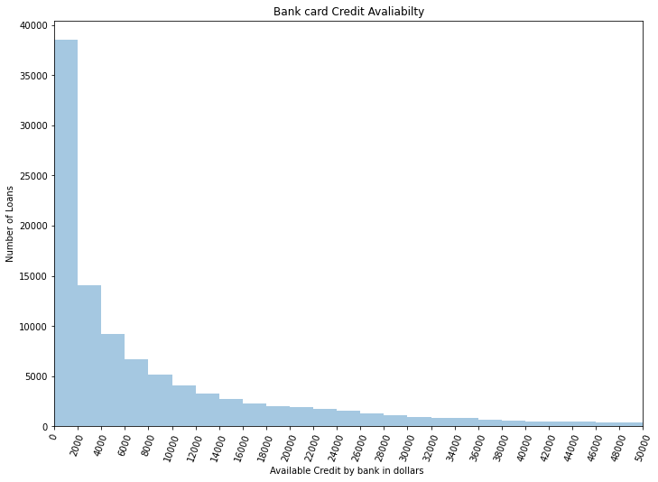

## (Distribution BankcardUtilization)

> We will continue to invistgate credit satatues of the dataset since it is importnat foactor for an investor to take decide to invest and also iportant calcluting estimited yeld rate

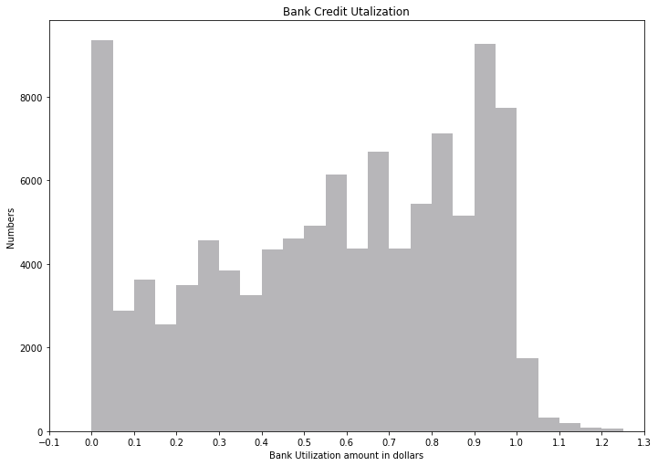

## (Catgorical variables affecting my variable of tnterset )

> Now we will explore more features realted the borrowers beahviour and affecting investor/lener
> - It seems that employment_satus feature is afcting as employed borrowers are the hieghst to recive loans while retired , not emplyed and part time employed borrowers are the lowset among borrowers
- pepole with income from 50000- 75000 tends to borrow more than 75000-10000+

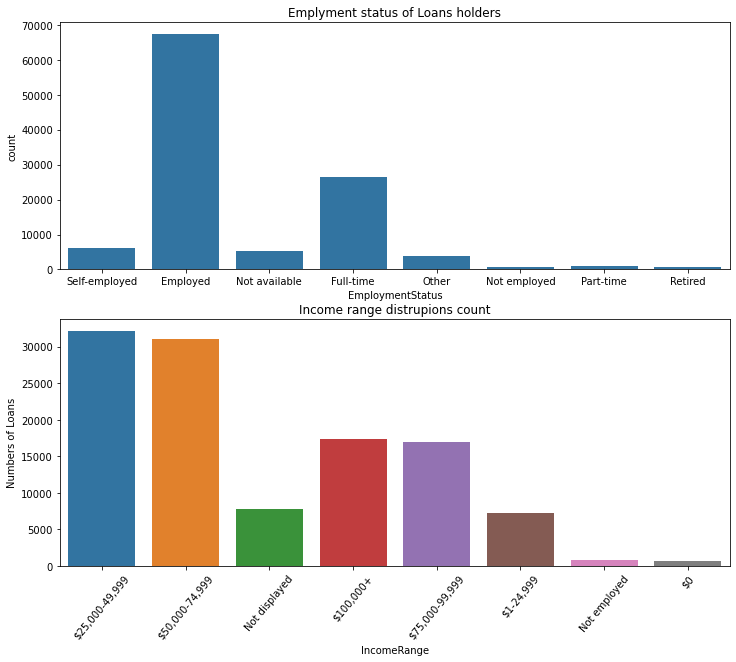

## (EstimatedEffectiveYield vs Loan lisiting Catgory)

> IN this plot lets plot loan listing catgory with our variable of interset EstimatedEffectiveYield to observe patterns in the loans catgories
> - In this graph we can notice the avrage for the various types of loans is almost around 15-20% estmited effective yeild rate expect for some types
> - Dept conslidation type have alot of the ouliers (data more than 1.5 from the avrage) which is below 0% effictive yeild meaaning estmiated losses ,this type of loan aborrower obtains a new loans to pay out a number of smaller loans, debts, or bills that they are currently making payments on .

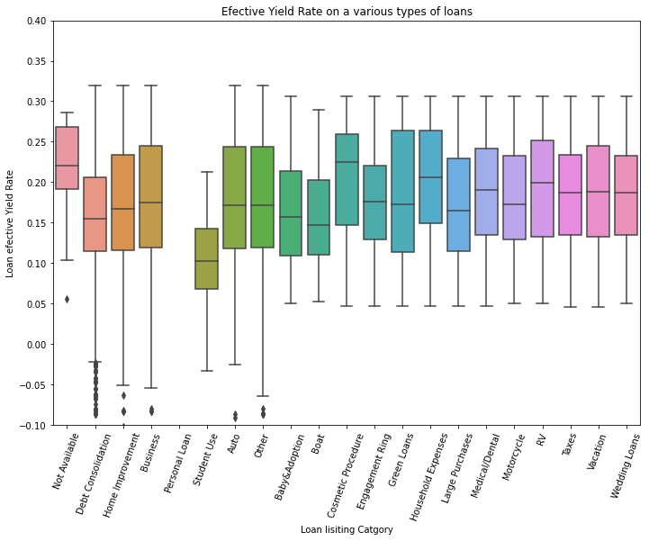

## (EstimatedEffectiveYield with every ProsperRating)

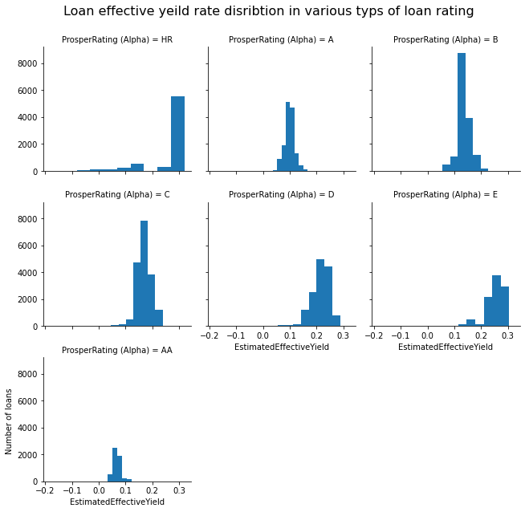

## (Investors prefernces and behaviour)

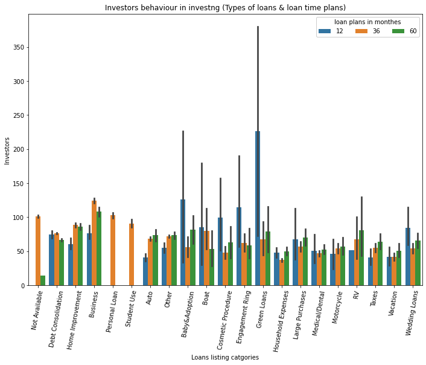